# Introduction to scRNA-seq - Part II: Pre-processing and Dimensionality Reduction

Maria Vlachonikolou

30/05/2023

# Normalizing, Variable Features and Scaling

After filtering low-quality cells and empty droplets out of the data set, the next step is to normalize, identify the highly variable features and scale.

## Loading the required packages

```r
library(Seurat)
```

## Loading the data of our previous session

```r
ple5 <- readRDS("srt_01_ple5v2.rds")
```

```r
ple5
```

```
## An object of class Seurat
## 13103 features across 2334 samples within 1 assay
## Active assay: RNA (13103 features, 0 variable features)
```

Having started with 16882 genes across 99634 cells, we are now left with 13103 genes across 2334 cells.

## Normalizing

Normalization aims to correcting for differences in sequencing depth, that way ensuring that the cells will be separated based on biological differences and not technical artifacts.

The read depth across the cells may vary significantly and this does not always have biological causes, but is often result of technical factors. Thus, it is more useful to evaluate the gene counts in comparison to the total amount of reads for each cell, making them comparable across the data set. This is achieved through the normalization of the data set, where feature counts for each cell are divided by the total counts of that cell and then multiplied by a scale factor and log-transformed.

After division by the total counts, the counts for each cell add up to 1. With a scaling factor of 10^4 it is ensured the counts after log-transformation will not be too low, but in a range that is easily comprehensible. The log transformation helps approximate a more symmetric distribution. allowing fo r the application of statistical tests or visualization methods that assume normality. Using log1p (logarithm of x+1) instead of log(x) ensures that counts of zero are transformed to a finite value.

```r
ple5 <- NormalizeData(ple5, normalization.method = "LogNormalize", scale.factor = 10000)
```

## Finding variable features

Our data contains some genes that have high variation of expression between cells and other genes that are more uniformly expressed. For our downstream analyses, we only select the highly variable genes.

*Questions to be answered in the protocol:*

- Why do we select only highly variable genes?

Our data set at the moment contains 13103 features/ dimensions which would require a large amount of computing power to analyse and is hard to interpret. Furthermore, most of them are more uniformly expressed between cells (e.g. housekeeping genes) and would not contribute significantly to the separation of cells in clusters. Focusing on the highly variable genes selection helps to highlight biological signal in single-cell data sets and reduce the required computing power.

- What might be reasons, why some genes are highly variable, while others are not?

Some genes such as house keeping genes, typically involved in basic cellular processes such as metabolism, protein synthesis, and cell structure maintenance, have constant expression levels across cell types and conditions.

On the other hand, there are genes that are highly variable across conditions, developmental stages and/or cell types. These genes may be involved in cell signaling, response to external stimuli, cell identity definition or specialized functions of specific cell types. These genes are extremely important in the context of clustering and downstream analysis to identify distinct cell populations within the data set and understand how different cell types arise.

Last, technical factors, batch effects and the inherent stochasticity of biological systems can also contribute to gene expression variability.

To find the top 2000 variable features the variance stabilizing transformation (vst) method is used. This method aims at generating a matrix of values for which variance is stabilized across the range of mean, especially for low mean values. That way, the over-contribution of low count genes with low signal-to-noise ratio is avoided.

First, the mean and variance of each gene is calculated using the unnormalized counts and a log-transformation is applied to both. Then, a curve is fitted to predict their relationship. The feature counts are standardized using the mean of raw values and the expected variance. As such, higher-than-expected variation is maintained. Finally, the variance of each gene is calculated on the standardized counts and is used to rank the genes.

```r
ple5 <- FindVariableFeatures(ple5, selection.method = "vst", nfeatures = 2000)
```

```r
plt <- VariableFeaturePlot(ple5)
plt.labels <- LabelPoints(
  plot = plt,
  points = head(VariableFeatures(ple5), 10),
  repel = TRUE, xnudge = 0, ynudge = 0
)
```

```r
plt.labels
```

[figure not shown]

Plot of mean expression vs standardized variance for each gene. The top 2000 genes with the highest variance are selected. 85% of the genes are deemed non-variable and are left out of downstream analysis.

## Scaling

The last pre-processing step is scaling. The ScaleData() function applies a linear transformation where the expression of each gene is shifted, so that the mean expression across cells is 0, and scaled, so that the variance across cells is 1. Because of this, highly and lowly expressed genes are given equal weights in the downstream analyses so that highly-expressed genes do not dominate.

```r
ple5 <- ScaleData(ple5)
```

# Dimensionality Reduction

Our data set is high-dimensional. In the following section we will reduce the dimensionality of our data set, which will make it easier to understand the underlying structure. This is a prerequisite for many downstream analyses.

*Questions to be answered in the protocol:*

- What are the dimensions of our data? How many dimensions/features does our data set have?

```r
dim(ple5)
```

```
## [1] 13103  2334
```

```r
dim(ple5[["RNA"]]@scale.data)
```

```
## [1] 2000 2334
```

Our data set consists of cells, each one described by a number of features such as the expression of genes, chromatin accessibility, percentage of mitochondrial genes etc. The dimensions of a dataset corresponds to the number of attributes/features that exist in it.

All features are considered dimensions, but usually, in the context of analysis such as this, only the gene expression is used, where each feature/gene is a dimension. We observe that the dimensions of the data remain the same, 13103, before and after calling FindVariableFeatures(), but the subsequent analysis will be performed on the selected variable features which are set to 2000.

Having available information about many characteristics (dimensions) for the data points can highlight differences and help with linear separation. But a high number of dimensions can also be a source of problems. As the number of dimensions increases we end up with fewer data points compared to the overall volume of the space. The amount of data needed tends to grow exponentially with the number of dimensions in order to obtain a reliable result. Moreover, our goal to cluster the data points becomes challenging as objects tend to appear sparse and dissimilar in many ways.

By selecting the highly variable genes the number of dimensions was reduced significantly. To further overcome this challenge linear and non-linear dimensionality reduction methods are utilized. The goal is to reduce the number of dimensions while keeping as much of the important information as possible.

- What are differences between linear and non-linear dimensionality reduction methods regarding their interpretability?

Linear dimensionality reduction methods, such as PCA, aim to find a lower-dimensional space that still describes most of the variance in the dataset. These methods produce linear combinations of the original features to create new dimensions. The resulting transformed dimensions are typically easier to interpret because they represent weighted combinations of the original features.

PCA finds eigenvectors that correlate with the highest variance in the dataset. These are called principal components and are sorted by the percentage of explained variance. Individual features (genes) of the dataset can be correlated with PCs and the positions of datapoints along the axes can be directly interpreted.

Non-linear dimensionality reduction methods, such as UMAP, presents an interesting alternative to linear methods which can capture non-linear relationships and complex patterns in the data though often at the expense of interpretability. The transformed dimensions generated by non-linear methods do not have a direct correspondence with the original features, making it challenging to interpret the specific meaning of each dimension. However, they are effective in visualizing clusters, local structures, and relationships between data points. In our case, cells with similar expression profiles will be close close to each other but the axis are no longer interpretable.

In summary, linear dimensionality reduction methods provide interpretable results as the transformed dimensions correspond to the original features. Non-linear methods, while powerful in capturing complex patterns, may lack direct interpretability as the transformed dimensions do not have a direct mapping to the original features. The choice between linear and non-linear methods depends on the specific goals of the analysis and the trade-off between interpretability and capturing complex relationships in the data.

This difference will become more clear later, as we apply these methods to the dataset.

## Linear dimensionality reduction

### Principal component analysis (PCA)

First, we perform PCA, a linear dimensionality reduction method. By default, only the previously determined variable features are used as input.

*Questions to be answered in the protocol:*

- What can we interpret from the PCA results?

PCA can be used to find patterns in highly complex datasets and identify the most important variables in the data. To achieve this, PCA combines linearly all variables (genes in our case) to produce new variables. These new variables are called Principle Components (PCs). In a geometric sense, principal components represent the directions of the data that explain a maximal amount of variance. All inital variables (features) in the dataset contribute to the construction of each principal component. However, the contribution of each variable is determined by the weights assigned to them, which reflect their correlation with the principal component.

PC1 is the one with the largest dispersion of the data points along it, that is to say, it carries the most information explaining the largest amount of variance. Each subsequent PC is determined through a similar procedure, ensuring that it is at right angle (uncorrelated) to the previous component(s), while also accounting for the next highest variance. In the end, the first few components are enough to give a faithful representation of the data.

(The interpretion of PCA results is also analysed after it is applied to the data, see bellow.)

- Below we explore the first two principal components; Also explore some of the other PCs!

```r
ple5 <- RunPCA(ple5, features = VariableFeatures(ple5))
```

```
## PC_ 1
## Positive:  SLC1A3, ATP1A2, SPARC, SEPP1, MDK, AHNAK, MEGF10, PTN, FAAH, SLC27A1
##     PPAP2B, FTL, MSI1, dally, VIM, B2M, FBLN5, ID3, SLC6A16, ENTPD2
##     SLC4A4, WNT7B, RARRES1, BCAN, KCNJ10, NOTCH3, lamb2, SLC25A18, SWAP70, FGFR2
## Negative:  SNAP25, RAB3A, SCG2, ARPP21, SCG5, CHGB, CAMK2A, CPE, PINLYP, LZTS1
##     FKBP1B, TIAM1, SYT1, ALDOC, C11orf96, SPOCK2, VSTM2A, PTPRN, SNCA, CHGA
##     UCHL1, PCSK1N, ATP1B1, CPLX1, SYT5, MAP2K1, BCL11B, CCER2, GPX3, PTPRN2
## PC_ 2
## Positive:  NTRK2, ADCYAP1R1, SLC6A16, BCAN, AQP4, LGI2, SLC16A1, GJA1, FADS2, C21orf62
##     PPAP2B, ACAN, SLC4A4, ARHGEF4, GPAM, FNDC4, lamb2, ADAMTS8, CYP7B1, FSTL5
##     CYP8B1, FGFR2, S1PR1, LOXL1, TIMP4, MEGF10, ANKRD6, SLC51A, MSI1, THBS3
## Negative:  C1QB, FYB, CFB, C1QA, CSF1R, LCP1, ARPC1B, CYBB, TREM2, PTPRC
##     TYROBP, RGS10, PIGR, S100A11, CD33, CLEC17A, MMRN1, LRRC25, MB21D1, C1QC
##     RGS1, CD68, ARHGAP27, HCK, DOCK2, F13A1, CRP, ATP6V0D2, CCL5, IGSF1
## PC_ 3
## Positive:  NPTXR, SLC17A7, NEUROD6, MAG, P2RY1, RTN4RL2, CPLX3, DIRAS2, WASF1, BHLHE22
##     ADAP1, FAM19A1, SYT5, FAM107A, ADCYAP1, NELL2, STON2, SPATA13, RTN4R, BTBD3
##     NRN1, GPC1, LINGO1, IQGAP2, CHGA, CAMKK2, NFIX, SFXN3, NEUROD4, SLC1A6
## Negative:  UNC13B, SHISA8, PCP4L1, SYNPR, MEIS3, RYR1, PPFIBP2, GAD2, KIAA0513, PLXNB2
##     TSHZ1, NRXN3, SP9, SLC32A1, KANK3, LPIN2, DLX3, RYR2, SYT10, ERBB4
##     GAD1, INPP5A, PBX3, ZADH2, DLX4, LAMP5, STAC2, RASSF8, CHRM4, SH3BP5
## PC_ 4
## Positive:  CSF1R, CYBB, C1QB, C1QC, FYB, C1QA, PIGR, CD33, PTPRC, LRRC25
##     CD68, RGS10, MMRN1, TREM2, TYROBP, F13A1, PLXNC1, PRSS16, CLEC17A, RGS1
##     CRP, UCP2, LCP1, MB21D1, HCK, CD5L, FCN2, ARHGAP27, CEACAM16, DOCK2
## Negative:  AEBP1, AGT, GJB6, APOE, OLFML3, SLC38A4, CST3, ATP8B3, FBLN1, COL20A1
##     COLEC12, RBP4, SLC6A13, AOC3, CLMP, BGN, SLC7A11, PAPLN, PTGDS, LOX
##     PCSK9, LUM, TGFBI, SLC13A2, PCOLCE, SULT1A1, COL1A2, DHRS2, KRT19, HPD
## PC_ 5
## Positive:  SNCA, EFR3B, ZEB2, ITPR1, MAG, RTN4RL2, KCNH3, SLC17A7, HTR6, ATP2A3
##     C1orf95, TIAM1, NEUROD6, GDPD5, RPRML, SYT6, FAM19A1, STX1A, STK32C, CPNE6
##     CPLX3, SLC1A6, NPTX2, TCF4, LZTS1, GRM1, KCNJ4, TNFRSF1B, NFIX, SHISA8
## Negative:  NOVA1, VAT1, GABRA3, RPH3A, ZFHX4, ina, SLC6A1, ZNF521, SEMA4G, ARHGAP24
##     UNC13C, GFRA4, EFNA5, FAM196A, ELAVL4, ALDOC, PCDH20, GPR151, FSTL4, SYNGR3
##     TUBA1B, ISL1, SCN5A, SLC32A1, RND2, CDH18, NECAB2, ID4, COL25A1, GAD2
```

By default 50 PCs are computed. The first five components, ranked in order of importance, are shown above. The top genes associated with the each principal component are listed. The weight of each gene in each PC is described by the loading score. Loading scores can take values from -1 to 1. The closer their value is to 0, the less variance they contribute to the PC.

```r
ple5@reductions$pca@feature.loadings[1:5, 1:5]
```

```
##               PC_1          PC_2          PC_3          PC_4         PC_5
## PTGDS  0.031791765 -0.0224987410 -8.999894e-03 -0.0866367485  0.009547048
## CST3   0.017750917 -0.0353650406 -4.070530e-03 -0.0981093140  0.011698731
## TAC1  -0.006214416  0.0001871832 -1.201650e-03 -0.0012971385 -0.044536429
## CCK   -0.005555299  0.0015227453 -2.635367e-03  0.0009080962 -0.027934353
## NPY   -0.006357517  0.0027996414 -3.372766e-05  0.0001437580 -0.035196625
```

We can visualize the top genes associated with the principal components (PCs).

```r
VizDimLoadings(ple5, dims = 1:2, reduction = "pca")
```

[figure not shown]

Visualization of top genes, ranked by the score absolut values, associated with reduction components. On the y axis the genes are listed. The PCA loadings are plotted on the x axis. Loadings can be positive or negative, depending on the correlation between the variable and the principal component. For example, cells with a high score on PC_1 will be those with high SLC1A3, ATP1A2, SPARC etc counts and low SNAP25, RAB3A, SCG2 etc counts. And the reverse would be true for cells with low PC_1 scores.

Plotting the cells in the PCA space:

```r
DimPlot(ple5, reduction = "pca", dims = 1:2)
```

[figure not shown]

In the PCA plot the correlations among all of the cells are converted into a 2D graph. Cells that are highly correlated have similar dimensions and so are grouped together. Differences along PC1 are more important than differences along PC2.

Highlighting gene expression:

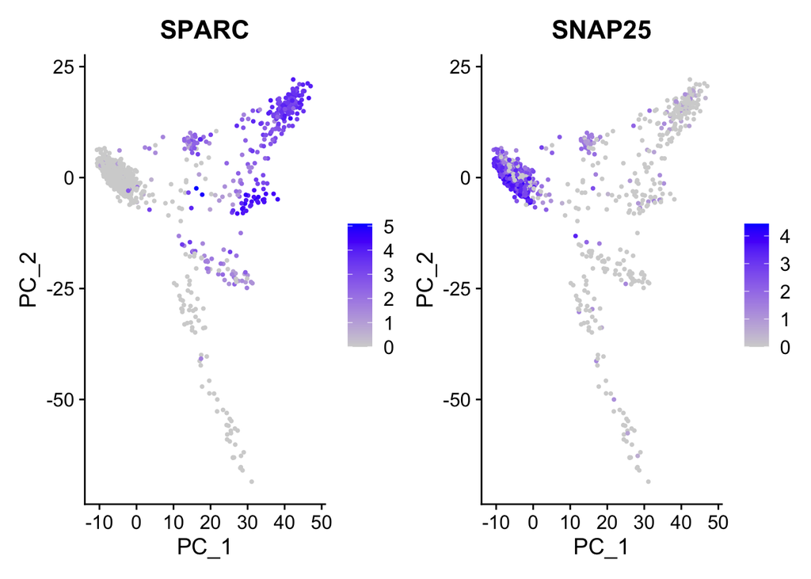

```r
FeaturePlot(ple5, c("SPARC", "SNAP25"), reduction = "pca", dims = 1:2)
```

In agreement to what was shown before, the correlation between SPARC (positive loading) and PC_1 is generally positive, while SNAP25 (negative loading) has a generally negative correlation with PC_1 and its expression is highest in cells with lowest scores for PC_1.

```r
mat <- Seurat::GetAssayData(ple5, assay = "RNA", slot = "scale.data")
pca <- ple5[["pca"]]

# Get the total variance:
total_variance <- sum(matrixStats::rowVars(mat))

eigValues = (pca@stdev)^2  ## EigenValues
varExplained = eigValues*100 / total_variance
varExplained
```

```
##  [1] 10.5737714  4.6976537  3.8647041  3.0307538  2.2405893  1.6031120
##  [7]  1.3100737  1.2638613  1.0549130  0.9429138  0.8195532  0.7624538
## [13]  0.7083019  0.6755063  0.6052581  0.5593938  0.5493709  0.5126438
## [19]  0.4716389  0.4469836  0.4408295  0.4166906  0.3752530  0.3625787
## [25]  0.3525696  0.3222166  0.3078237  0.2986939  0.2895930  0.2790761
## [31]  0.2709696  0.2660941  0.2604136  0.2569030  0.2462069  0.2443534
## [37]  0.2376956  0.2326426  0.2210402  0.2100923  0.2083614  0.2056909
## [43]  0.2037478  0.2003699  0.1936033  0.1914958  0.1904636  0.1837613
## [49]  0.1822375  0.1785559
```

The elbow plot can be used to find a cutoff for the number of PCs to use for downstream analyses. Generally it is better to use too many than too few. In this case, 30 PCs seems reasonable.

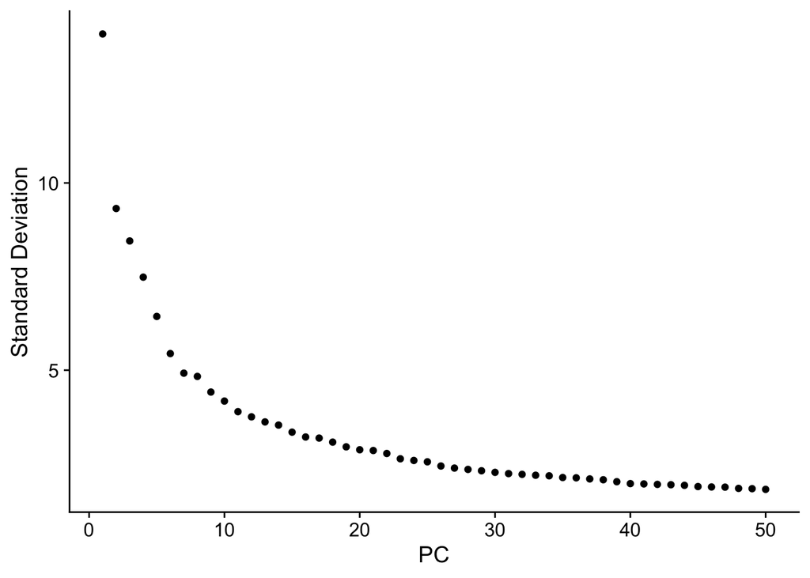

```r
ElbowPlot(ple5, ndims = 50)
```

The standard deviation indicates how much variation is explained by each PC. Higher standard deviation values indicate that the corresponding PC captures more variability in the data.

It is also possible to have a look into the percentage of each PCs contribution to the total variance.

```r
pca <- ple5[["pca"]]

# Get the total variance:
total_variance <- ple5@reductions$pca@misc$total.variance

eigValues = (pca@stdev)^2  ## EigenValues are SS(distances)/(n-1) for each PC
varExplained = eigValues*100 / total_variance
varExplained
```

```
##  [1] 10.5737714  4.6976537  3.8647041  3.0307538  2.2405893  1.6031120
##  [7]  1.3100737  1.2638613  1.0549130  0.9429138  0.8195532  0.7624538
## [13]  0.7083019  0.6755063  0.6052581  0.5593938  0.5493709  0.5126438
## [19]  0.4716389  0.4469836  0.4408295  0.4166906  0.3752530  0.3625787
## [25]  0.3525696  0.3222166  0.3078237  0.2986939  0.2895930  0.2790761
## [31]  0.2709696  0.2660941  0.2604136  0.2569030  0.2462069  0.2443534
## [37]  0.2376956  0.2326426  0.2210402  0.2100923  0.2083614  0.2056909
## [43]  0.2037478  0.2003699  0.1936033  0.1914958  0.1904636  0.1837613
## [49]  0.1822375  0.1785559
```

```r
sum(varExplained[1:7])
```

```
## [1] 27.32066
```

```r
sum(varExplained[1:30])
```

```
## [1] 40.13878
```

```r
sum(varExplained[1:50])
```

```
## [1] 44.52347
```

Note: These percentages seem to me rather low.

The first 7 PCs explain 27% of variance in the original data (2000 features).  
The first 30 PCs explain 40% of variance in the original data.  
All 50 computed PCs explain 44% of variance in the original data. Note: In the PCA analysis, by default, only the first 50 PCs are computed. But it is possible to have as many PCs as variables in the original data set.

## Non-linear dimensionality reduction

t-SNE and UMAP will be performed. These two are non-linear dimensionality reduction methods.

In many scRNA-seq analysis workflows, PCA is often used as a preprocessing step to reduce the dimensionality of the data set. The resulting PCA components can then be used as input to non-linear dimensionality reduction methods, such as t-SNE and UMAP, for further visualization and clustering analysis. While linear and non-linear dimensionality reduction methods are often used together in scRNA-seq analysis, they serve different purposes and have different mathematical foundations.

*Questions to be answered in the protocol:*

- We chose 30 PCs for the t-SNE and UMAP, based on the elbow plot above. Also try some different values and compare the results.

### Non-linear dimensionality reduction for **30 PCs**

### t-distributed stochastic neighbor embedding (t-SNE)

```r
ple5 <- RunTSNE(ple5, dims = 1:30)
```

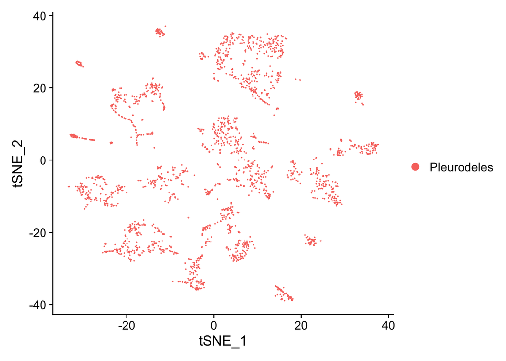

```r
DimPlot(ple5, reduction = "tsne", pt.size = 0.05)
```

In the plot, the x-axis and y-axis represent the new coordinates of the data points in the reduced dimensional space, without being assigned to certain original features of the dataset. The distances and relationships between points in this space are meaningful to a degree, but the actual values on the axes do not have direct interpretations. Some areas in the plot have higher density, indicating groups consisting of cells that are similar to each other. In our case it means that cells which are grouped into the same cluster have similar gene expression patterns, possibly because they belong to the same cell type.

While t-SNE is designed to preserve the local structure, it does not perform well in terms of global structure preservation. The distances between the clusters cannot be interpreted with certainty and in many cases they mean nothing. So, two clusters that are closer in the graph are not necessarily more similar.

Additionally, the area of each cluster is not meaningful. The algorithm adjusts the size of the cluster (bounding box measurements, not number of points) so that they have more or less the same density. This translates to dense clusters being expanded and sparse ones contracted. Thus, sizes of clusters in t-SNE graphs such as the above should not be compared.

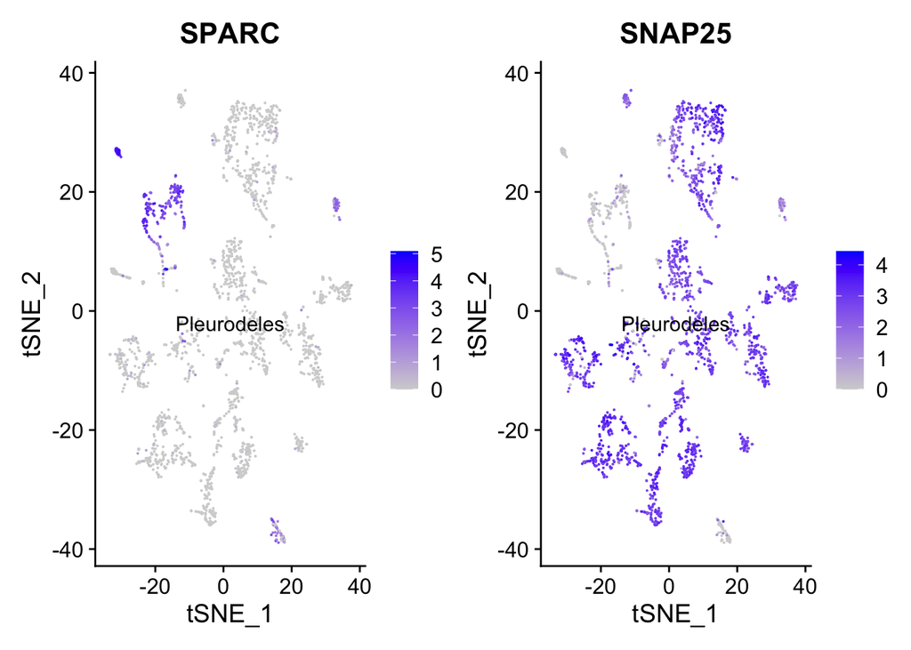

```r
FeaturePlot(ple5, c("SPARC", "SNAP25"), reduction = "tsne", pt.size = 0.05, label=T)
```

The expression of SPARC and SNAP25 seem to be, in general, mutually exclusive, splitting the cells into two categories.

### Uniform manifold approximation and projection (UMAP)

UMAP is similar to t-SNE, but it has a number of advantages over it. UMAP is faster, performing better in terms of both data set size and dimensionality. It also manages to preserve better the global structure of the data and separates more clearly groups of similar categories from each other. Additionally, t-SNE projections exhibit high variability across runs, while UMAP consistently produces similar projections with different runs and parameters. This is again attributed to UMAP’s stronger focus on global structure.

```r
ple5 <- RunUMAP(ple5, dims = 1:30)
```

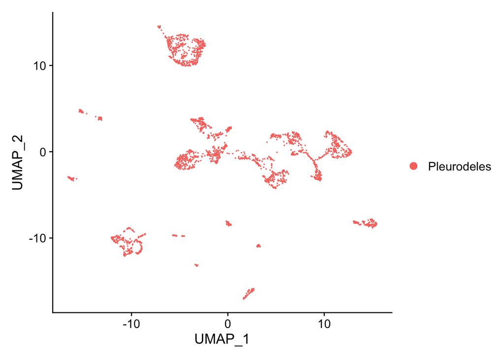

```r
DimPlot(ple5, reduction = "umap", pt.size = 0.05)
```

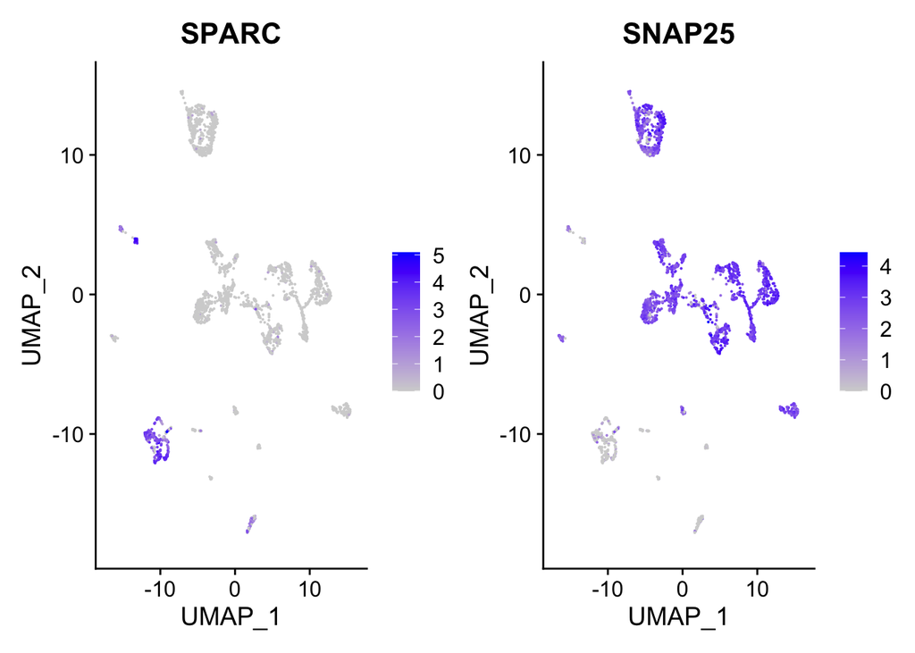

```r
FeaturePlot(ple5, c("SPARC", "SNAP25"), reduction = "umap", pt.size = 0.05)
```

UMAP and t-SNE differ mainly in their ability to preserve global structure in the projected data. UMAP tends to better retain inter-cluster relations. However, neither UMAP nor t-SNE allow for direct interpretation of axes or distances in lower dimensions like PCA does. Although UMAP indeed preserves the global positions of clusters more effectively, the distances between them possibly lack meaningful interpretation. This is attributed to the utilization of local distances during the construction of the graph. For the same reason, again, similarly to t-SNE, cluster sizes in a UMAP plot mean nothing.

It is noticeable here that the data points in the t-SNE graph are more spread out compared to UMAP. In UMAP they appear to cluster more tightly on the graph and are better separated. It is possible to achieve better global structure results with t-SNE by increasing the perplexity, but this would require much longer computation time.

# Saving the Seurat object for later use

```r
saveRDS(ple5, "srt_02_ple5v2.rds")
```

### Exploring non-linear dimensionality reduction for **7 PCs**

```r
ple5 <- RunTSNE(ple5, dims = 1:7)
```

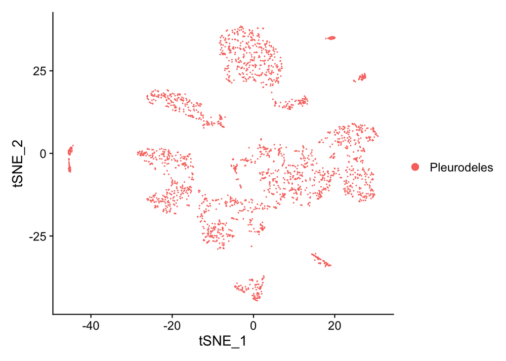

```r
DimPlot(ple5, reduction = "tsne", pt.size = 0.05)
```

```r
ple5 <- RunUMAP(ple5, dims = 1:7)
```

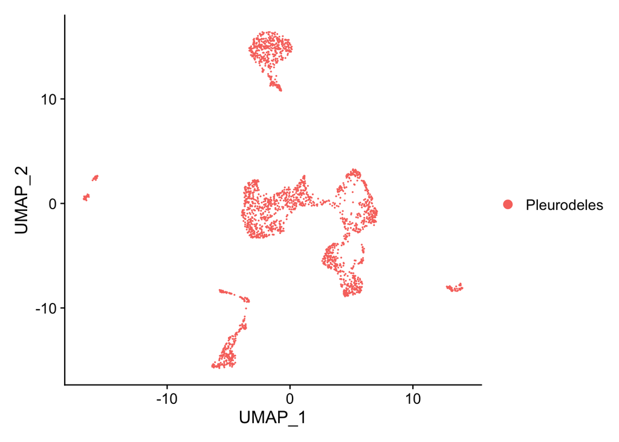

```r
DimPlot(ple5, reduction = "umap", pt.size = 0.05)
```

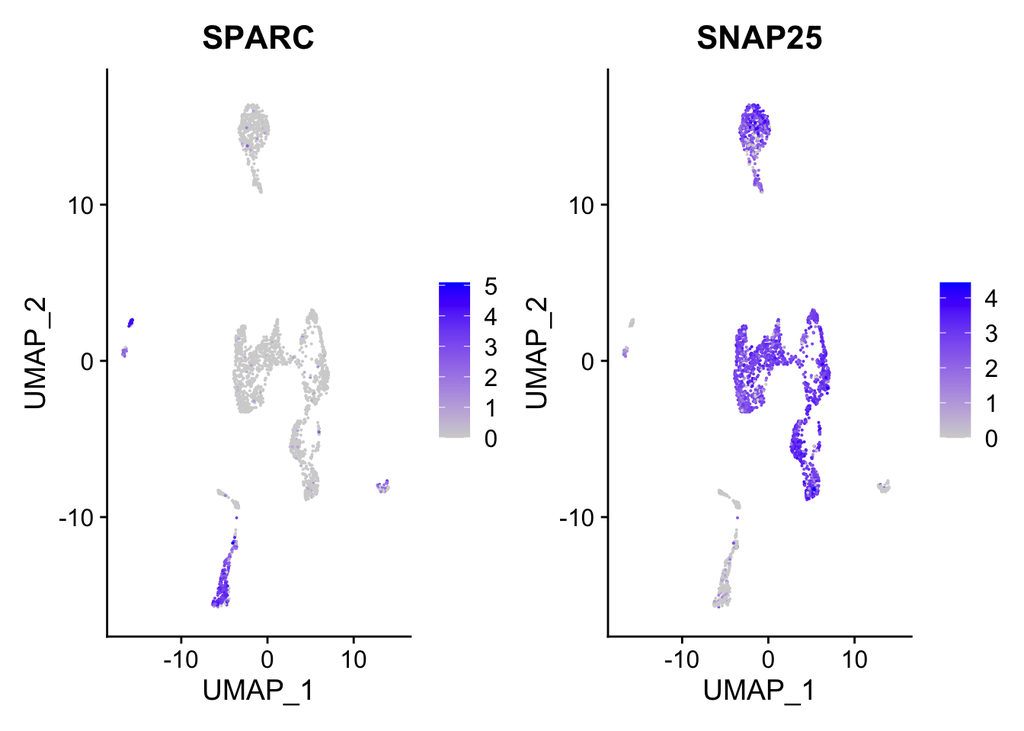

```r
FeaturePlot(ple5, c("SPARC", "SNAP25"), reduction = "umap", pt.size = 0.05)
```

The clustering results presented above effectively capture the distinct expression differences of SPARC and SNAP25. These two genes are strongly associated with the first principle component which is included in the analysis.

Bellow the expression patterns of two genes associated with the tenth principle component are plotted.

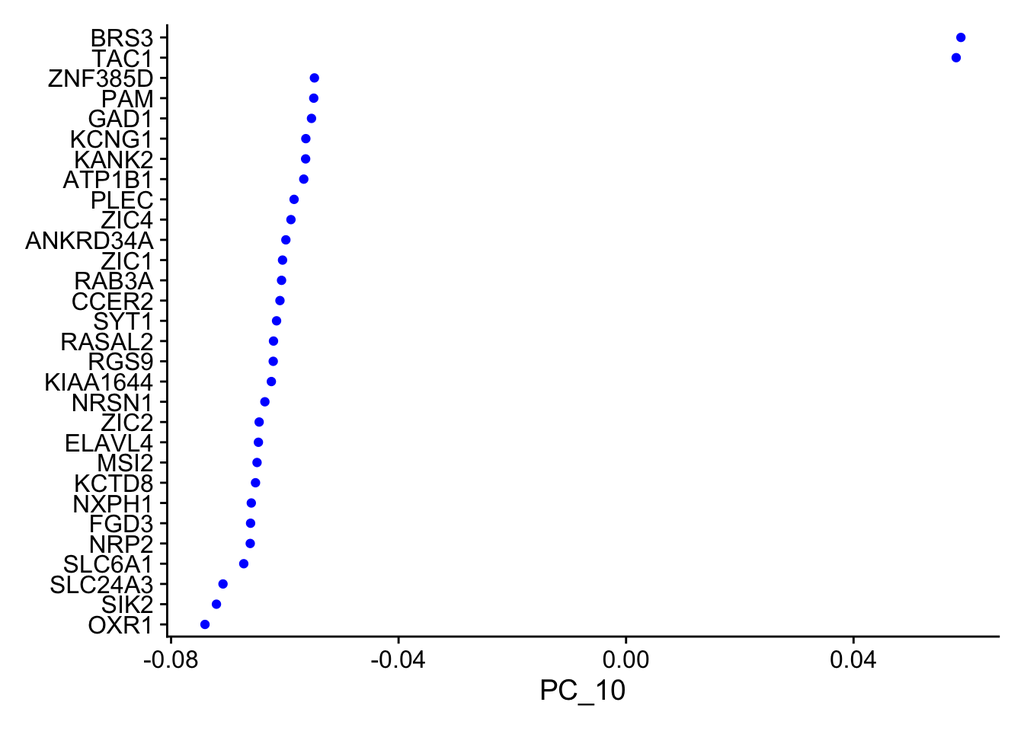

```r
VizDimLoadings(ple5, dims = 10, reduction = "pca")
```

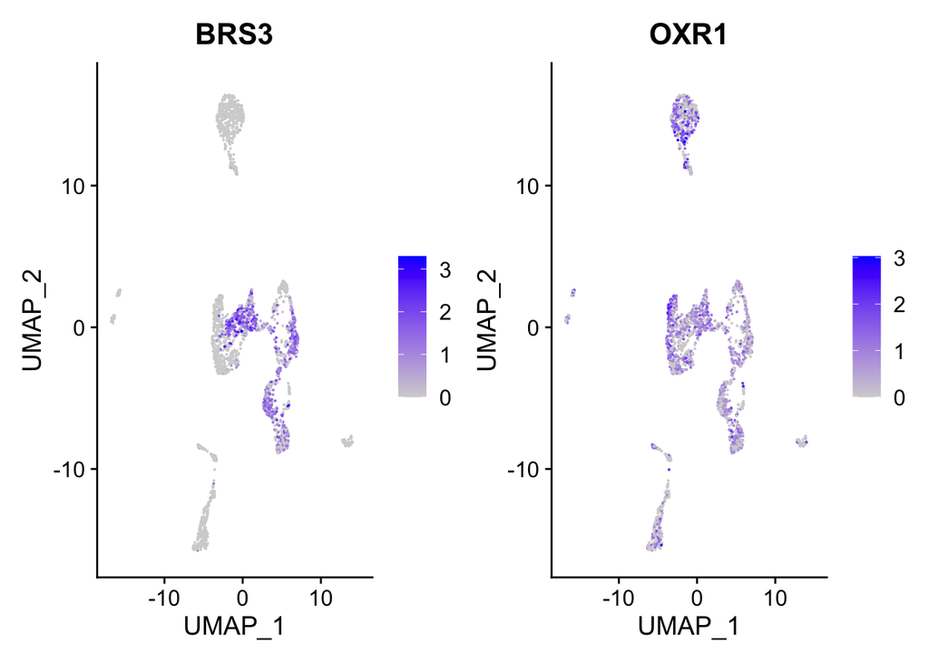

```r
FeaturePlot(ple5, c("BRS3", "OXR1"), reduction = "umap", pt.size = 0.05)
```

In this case results are more “mixed”.

### Non-linear dimensionality reduction for **50 PCs**

```r
ple5 <- RunTSNE(ple5, dims = 1:50)
```

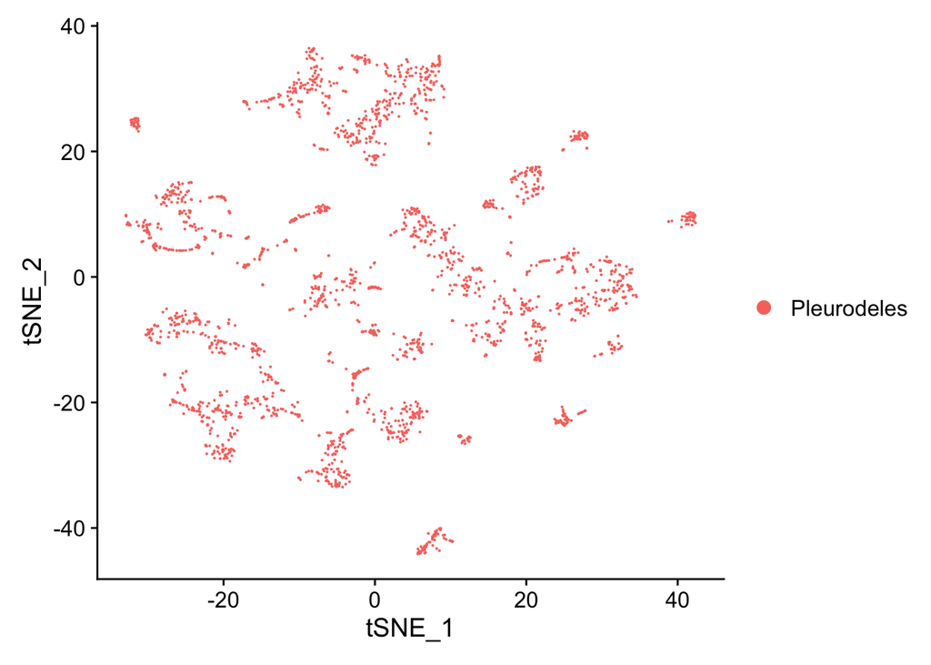

```r
DimPlot(ple5, reduction = "tsne", pt.size = 0.05)
```

```r
ple5 <- RunUMAP(ple5, dims = 1:50)
```

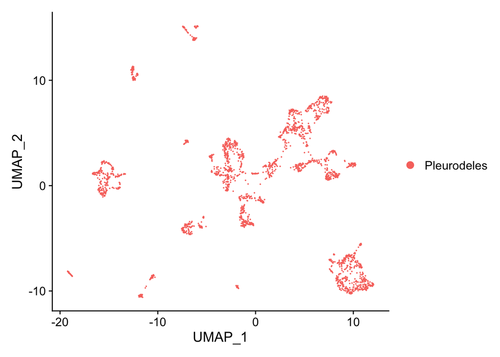

```r
DimPlot(ple5, reduction = "umap", pt.size = 0.05)
```

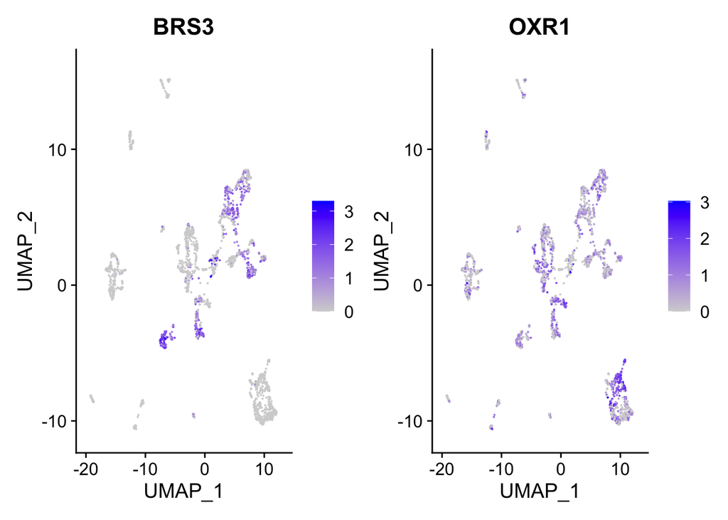

```r
FeaturePlot(ple5, c("BRS3", "OXR1"), reduction = "umap", pt.size = 0.05)
```

Even at 50 dims OXR1 expression is not well clustered, but BRS3 correlates better to specific groups.

Choosing the optimal number of PCs can be challenging. Adding more PCs in t-SNE and UMAP analyses allows for capturing additional variance in the data and define rare subsets. But, as PCs are arranged in decreasing order of variance, the higher the number of PCs included, the lower the signal-to-noise ratio.

A low number of PCs provides with a more generalized representation of the data structure. This can be beneficial when seeking to highlight broader patterns, but may also lead to oversimplification.

Thus, the optimal number of PCs to include depends on the specific data set and the desired level of detail according to the goals of the analysis. Here, the results of 30 vs 50 PCs do not differ dramatically. But running UMAP and t-SNE with only 7 principle components results in much less clusters which do not take into account the variable expression of genes which are not associated strongly to the first 7 PCs.

Based on the Elbow Plot and previous experience 30 PCs will be used for further downstream analyses.